# Ajinkya Kobal_Project-15_Regression Analysis

### 1.2) Control variables

```python
Awhat1=pd.get_dummies(Sadata['year'], prefix='y')
Sadata = Sadata.merge(Awhat1, how='inner', left_index=True, right_index=True)
Sadata.head()
```

|  | cik | gvkey | datadate | conm | revt | ni | year | month | Real_income | norm | ... | y_2013 | y_2014 | y_2015 | y_2016 | y_2017 | y_2018 | y_2019 | y_2020 | y_2021 | y_2022 |
| --- | --- | --- | --- | --- | --- | --- | --- | --- | --- | --- | --- | --- | --- | --- | --- | --- | --- | --- | --- | --- | --- |
| 0 | 0000778946 | 011877 | 2000-03-31 | BLUEGREEN VACATNS CORP | 247.673 | 6.777 | 2000 | 3 | 11677.540167 | 124.3365 | ... | False | False | False | False | False | False | False | False | False | False |
| 1 | 0001408100 | 025632 | 2000-12-31 | KENNEDY-WILSON HOLDINGS INC | 92.737 | 4.726 | 2000 | 12 | 11677.540167 | 46.8685 | ... | False | False | False | False | False | False | False | False | False | False |
| 2 | 0001057507 | 110729 | 2000-12-31 | RESORTQUEST INTL INC | 152.014 | 9.606 | 2000 | 12 | 11677.540167 | 76.5070 | ... | False | False | False | False | False | False | False | False | False | False |
| 3 | 0000216039 | 005357 | 2000-06-30 | GRUBB & ELLIS CO | 413.535 | 16.290 | 2000 | 6 | 11677.540167 | 207.2675 | ... | False | False | False | False | False | False | False | False | False | False |
| 4 | 0000820917 | 024203 | 2000-12-31 | EQUIVEST FINANCE INC | 158.256 | 10.444 | 2000 | 12 | 11677.540167 | 79.6280 | ... | False | False | False | False | False | False | False | False | False | False |

5 rows × 48 columns

```python
Amodel3 = smf.ols(formula='log_revt ~ Real_income+y_2013+y_2014+y_2015+y_2016+y_2017+y_2018+y_2019+y_2020+y_2021', data=Sadata)
Aresults3 = Amodel3.fit()
print(Aresults3.summary())
```

```
                            OLS Regression Results
==============================================================================
Dep. Variable:               log_revt   R-squared:                       0.259
Model:                            OLS   Adj. R-squared:                  0.245
Method:                 Least Squares   F-statistic:                     19.28
Date:                Mon, 04 Dec 2023   Prob (F-statistic):           1.40e-30
Time:                        00:06:51   Log-Likelihood:                -1238.0
No. Observations:                 564   AIC:                             2498.
Df Residuals:                     553   BIC:                             2546.
Df Model:                          10
Covariance Type:            nonrobust
==================================================================================
                     coef    std err          t      P>|t|      [0.025      0.975]
----------------------------------------------------------------------------------
Intercept         -0.5383      0.464     -1.160      0.246      -1.450       0.373
y_2013[T.True]    -0.1497      0.555     -0.270      0.787      -1.239       0.940
y_2014[T.True]    -0.1404      0.611     -0.230      0.818      -1.340       1.060
y_2015[T.True]    -0.0746      0.581     -0.128      0.898      -1.216       1.067
y_2016[T.True]    -0.2136      0.568     -0.376      0.707      -1.330       0.903
y_2017[T.True]     0.3619      0.606      0.597      0.551      -0.829       1.553
y_2018[T.True]     0.2640      0.581      0.454      0.650      -0.877       1.405
y_2019[T.True]     0.2913      0.563      0.518      0.605      -0.814       1.397
y_2020[T.True]    -0.4735      0.532     -0.890      0.374      -1.519       0.572
y_2021[T.True]    -0.5659      0.529     -1.069      0.286      -1.606       0.474
Real_income        0.0004   3.82e-05      9.800      0.000       0.000       0.000
==============================================================================
Omnibus:                       39.847   Durbin-Watson:                   1.948
Prob(Omnibus):                  0.000   Jarque-Bera (JB):               47.227
Skew:                          -0.707   Prob(JB):                     5.56e-11
Kurtosis:                       2.891   Cond. No.                     1.36e+05
==============================================================================

Notes:
[1] Standard Errors assume that the covariance matrix of the errors is correctly specified.
[2] The condition number is large, 1.36e+05. This might indicate that there are
strong multicollinearity or other numerical problems.
```

**Observation :**

**1) Prob (F-statistic) - This value is <0.1, so we will consider this regression analysis.**

**3) Coef - 0.0004 which is positive**

#

# 2) Regression Analysis (Revenue & Interest Rate) ====================

```python
Bmodel1=smf.ols(formula='revt~Interest_rate',data=Ajdata)
Bresults1=Bmodel1.fit()
print(Bresults1.summary())
```

```
                            OLS Regression Results
==============================================================================
Dep. Variable:                   revt   R-squared:                       0.096
Model:                            OLS   Adj. R-squared:                  0.095
Method:                 Least Squares   F-statistic:                     59.90
Date:                Mon, 04 Dec 2023   Prob (F-statistic):           4.65e-14
Time:                        00:06:52   Log-Likelihood:                -5268.8
No. Observations:                 565   AIC:                         1.054e+04
Df Residuals:                     563   BIC:                         1.055e+04
Df Model:                           1
Covariance Type:            nonrobust
=================================================================================
                    coef    std err          t      P>|t|      [0.025      0.975]
---------------------------------------------------------------------------------
Intercept      2421.3974    186.917     12.954      0.000    2054.258    2788.537
Interest_rate  -639.9209     82.684     -7.739      0.000    -802.328    -477.514
==============================================================================
Omnibus:                      594.547   Durbin-Watson:                   1.807
Prob(Omnibus):                  0.000   Jarque-Bera (JB):            30852.401
Skew:                           4.819   Prob(JB):                         0.00
Kurtosis:                      37.895   Cond. No.                         4.18
==============================================================================

Notes:
[1] Standard Errors assume that the covariance matrix of the errors is correctly specified.
```

**Observation :**

```python
import matplotlib.pyplot as plt

plt.hist(Ajdata['revt'],bins=20)
plt.show()
```

[output not shown]

**Observation : Revenue distribution is significantly skewed.**

### 2.1) log transformation

```python
import numpy as np
Ajdata['norm'] = (1+Ajdata.revt)/2
Ajdata['log_revt'] = np.log(Ajdata['norm'])
Ajdata.head()
```

|  | cik | gvkey | datadate | conm | revt | ni | year | month | Interest_rate | norm | log_revt |
| --- | --- | --- | --- | --- | --- | --- | --- | --- | --- | --- | --- |
| 0 | 0000778946 | 011877 | 2000-03-31 | BLUEGREEN VACATNS CORP | 247.673 | 6.777 | 2000 | 3 | 3.116589 | 124.3365 | 4.822992 |
| 1 | 0001408100 | 025632 | 2000-12-31 | KENNEDY-WILSON HOLDINGS INC | 92.737 | 4.726 | 2000 | 12 | 3.116589 | 46.8685 | 3.847346 |
| 2 | 0001057507 | 110729 | 2000-12-31 | RESORTQUEST INTL INC | 152.014 | 9.606 | 2000 | 12 | 3.116589 | 76.5070 | 4.337382 |
| 3 | 0000216039 | 005357 | 2000-06-30 | GRUBB & ELLIS CO | 413.535 | 16.290 | 2000 | 6 | 3.116589 | 207.2675 | 5.334010 |
| 4 | 0000820917 | 024203 | 2000-12-31 | EQUIVEST FINANCE INC | 158.256 | 10.444 | 2000 | 12 | 3.116589 | 79.6280 | 4.377366 |

```python
import matplotlib.pyplot as plt

plt.hist(Ajdata['log_revt'])
plt.show()
```

[output not shown]

**Observation : After Log transformation the Revenue is Evenly Distributed.**

```python
Ajdata.describe()
```

|  | datadate | revt | ni | year | month | Interest_rate | norm | log_revt |
| --- | --- | --- | --- | --- | --- | --- | --- | --- |
| count | 572 | 565.000000 | 565.000000 | 572.000000 | 572.000000 | 572.000000 | 565.000000 | 564.000000 |
| mean | 2007-03-17 15:08:48.671328768 | 1277.414473 | 12.823004 | 2006.291958 | 11.013986 | 1.799518 | 639.207236 | 4.434322 |
| min | 1986-12-31 00:00:00 | -356.790000 | -1912.000000 | 1986.000000 | 1.000000 | -0.119478 | -177.895000 | -0.693147 |
| 25% | 1998-01-23 06:00:00 | 36.151000 | -4.765000 | 1997.750000 | 12.000000 | 0.589024 | 18.575500 | 2.970877 |
| 50% | 2007-12-31 00:00:00 | 255.030000 | 1.192000 | 2007.000000 | 12.000000 | 1.445796 | 128.015000 | 4.865459 |
| 75% | 2016-12-31 00:00:00 | 904.499000 | 24.557000 | 2016.000000 | 12.000000 | 3.116589 | 452.749500 | 6.116614 |
| max | 2022-12-31 00:00:00 | 30828.246000 | 1407.370000 | 2022.000000 | 12.000000 | 4.452901 | 15414.623000 | 9.643072 |
| std | NaN | 2857.895545 | 219.147399 | 10.466546 | 2.584437 | 1.385928 | 1428.947773 | 2.526005 |

```python
Bmodel2=smf.ols(formula='log_revt~Interest_rate',data=Ajdata)
Bresults=Bmodel2.fit()
print(Bresults.summary())
```

```
                            OLS Regression Results
==============================================================================
Dep. Variable:               log_revt   R-squared:                       0.203
Model:                            OLS   Adj. R-squared:                  0.201
Method:                 Least Squares   F-statistic:                     142.8
Date:                Mon, 04 Dec 2023   Prob (F-statistic):           1.76e-29
Time:                        00:06:55   Log-Likelihood:                -1258.6
No. Observations:                 564   AIC:                             2521.
Df Residuals:                     562   BIC:                             2530.
Df Model:                           1
Covariance Type:            nonrobust
=================================================================================
                    coef    std err          t      P>|t|      [0.025      0.975]
---------------------------------------------------------------------------------
Intercept         5.9003      0.155     38.015      0.000       5.595       6.205
Interest_rate    -0.8202      0.069    -11.949      0.000      -0.955      -0.685
==============================================================================
Omnibus:                       35.268   Durbin-Watson:                   1.804
Prob(Omnibus):                  0.000   Jarque-Bera (JB):               40.819
Skew:                          -0.655   Prob(JB):                     1.37e-09
Kurtosis:                       2.849   Cond. No.                         4.17
==============================================================================

Notes:
[1] Standard Errors assume that the covariance matrix of the errors is correctly specified.
```

**Observation :**

### 2.2) Control variables

```python
Bwhat1=pd.get_dummies(Ajdata['year'], prefix='y')
Ajdata = Ajdata.merge(Bwhat1, how='inner', left_index=True, right_index=True)
Ajdata.head()
```

|  | cik | gvkey | datadate | conm | revt | ni | year | month | Interest_rate | norm | ... | y_2013 | y_2014 | y_2015 | y_2016 | y_2017 | y_2018 | y_2019 | y_2020 | y_2021 | y_2022 |
| --- | --- | --- | --- | --- | --- | --- | --- | --- | --- | --- | --- | --- | --- | --- | --- | --- | --- | --- | --- | --- | --- |
| 0 | 0000778946 | 011877 | 2000-03-31 | BLUEGREEN VACATNS CORP | 247.673 | 6.777 | 2000 | 3 | 3.116589 | 124.3365 | ... | False | False | False | False | False | False | False | False | False | False |
| 1 | 0001408100 | 025632 | 2000-12-31 | KENNEDY-WILSON HOLDINGS INC | 92.737 | 4.726 | 2000 | 12 | 3.116589 | 46.8685 | ... | False | False | False | False | False | False | False | False | False | False |
| 2 | 0001057507 | 110729 | 2000-12-31 | RESORTQUEST INTL INC | 152.014 | 9.606 | 2000 | 12 | 3.116589 | 76.5070 | ... | False | False | False | False | False | False | False | False | False | False |
| 3 | 0000216039 | 005357 | 2000-06-30 | GRUBB & ELLIS CO | 413.535 | 16.290 | 2000 | 6 | 3.116589 | 207.2675 | ... | False | False | False | False | False | False | False | False | False | False |
| 4 | 0000820917 | 024203 | 2000-12-31 | EQUIVEST FINANCE INC | 158.256 | 10.444 | 2000 | 12 | 3.116589 | 79.6280 | ... | False | False | False | False | False | False | False | False | False | False |

5 rows × 48 columns

```python
Bmodel2 = smf.ols(formula='log_revt ~ Interest_rate+y_2013+y_2014+y_2015+y_2016+y_2017+y_2018+y_2019+y_2020+y_2021', data=Ajdata)
Bresults2 = Bmodel2.fit()
print(Bresults2.summary())
```

```
                            OLS Regression Results
==============================================================================
Dep. Variable:               log_revt   R-squared:                       0.223
Model:                            OLS   Adj. R-squared:                  0.209
Method:                 Least Squares   F-statistic:                     15.89
Date:                Mon, 04 Dec 2023   Prob (F-statistic):           3.07e-25
Time:                        00:06:56   Log-Likelihood:                -1251.2
No. Observations:                 564   AIC:                             2524.
Df Residuals:                     553   BIC:                             2572.
Df Model:                          10
Covariance Type:            nonrobust
==================================================================================
                     coef    std err          t      P>|t|      [0.025      0.975]
----------------------------------------------------------------------------------
Intercept          5.6370      0.243     23.175      0.000       5.159       6.115
y_2013[T.True]    -0.6146      0.588     -1.046      0.296      -1.769       0.540
y_2014[T.True]    -0.1647      0.631     -0.261      0.794      -1.405       1.076
y_2015[T.True]     0.1390      0.595      0.234      0.815      -1.030       1.308
y_2016[T.True]    -0.0274      0.584     -0.047      0.963      -1.174       1.120
y_2017[T.True]     0.9612      0.609      1.577      0.115      -0.236       2.158
y_2018[T.True]     1.3756      0.567      2.426      0.016       0.262       2.490
y_2019[T.True]     1.1494      0.553      2.078      0.038       0.063       2.236
y_2020[T.True]     0.2824      0.524      0.539      0.590      -0.746       1.311
y_2021[T.True]     0.5878      0.497      1.182      0.238      -0.389       1.565
Interest_rate     -0.7436      0.091     -8.155      0.000      -0.923      -0.565
==============================================================================
Omnibus:                       33.116   Durbin-Watson:                   1.847
Prob(Omnibus):                  0.000   Jarque-Bera (JB):               37.877
Skew:                          -0.629   Prob(JB):                     5.96e-09
Kurtosis:                       2.830   Cond. No.                         21.5
==============================================================================

Notes:
[1] Standard Errors assume that the covariance matrix of the errors is correctly specified.
```

**Observation :**

**1) Prob (F-statistic) - This value is <0.1, so we will consider this regression analysis.**

# 3) Regression Analysis (Revenue & House Price) =====================

```python
Cmodel1=smf.ols(formula='revt~House_price',data=datamerge)
Cresults1=Cmodel1.fit()
print(Cresults1.summary())
```

```
                            OLS Regression Results
==============================================================================
Dep. Variable:                   revt   R-squared:                       0.195
Model:                            OLS   Adj. R-squared:                  0.194
Method:                 Least Squares   F-statistic:                     136.6
Date:                Mon, 04 Dec 2023   Prob (F-statistic):           2.16e-28
Time:                        00:06:57   Log-Likelihood:                -5227.1
No. Observations:                 564   AIC:                         1.046e+04
Df Residuals:                     562   BIC:                         1.047e+04
Df Model:                           1
Covariance Type:            nonrobust
===============================================================================
                  coef    std err          t      P>|t|      [0.025      0.975]
-------------------------------------------------------------------------------
Intercept   -1743.1615    280.298     -6.219      0.000   -2293.720   -1192.603
House_price    20.3662      1.743     11.685      0.000      16.943      23.790
==============================================================================
Omnibus:                      544.171   Durbin-Watson:                   2.036
Prob(Omnibus):                  0.000   Jarque-Bera (JB):            23185.075
Skew:                           4.237   Prob(JB):                         0.00
Kurtosis:                      33.246   Cond. No.                         417.
==============================================================================

Notes:
[1] Standard Errors assume that the covariance matrix of the errors is correctly specified.
```

**Observation :**

**1) Prob (F-statistic) - This value is <0.1, so we will consider this regression analysis.**

**3) coef - Value is positive.**

```python
import matplotlib.pyplot as plt

plt.hist(datamerge['revt'],bins=20)
plt.show()
```

[output not shown]

**Observation : Revenue distribution is significantly skewed.**

### 3.1) log transformation

```python
import numpy as np
datamerge['norm'] = (1+datamerge.revt)/2
datamerge['log_revt'] = np.log(datamerge['norm'])
datamerge.head()
```

|  | cik | gvkey | datadate | conm | revt | ni | year | month | House_price | norm | log_revt |
| --- | --- | --- | --- | --- | --- | --- | --- | --- | --- | --- | --- |
| 0 | 0000778946 | 011877 | 2000-03-31 | BLUEGREEN VACATNS CORP | 247.673 | 6.777 | 2000 | 3 | 104.777 | 124.3365 | 4.822992 |
| 1 | 0001408100 | 025632 | 2000-12-31 | KENNEDY-WILSON HOLDINGS INC | 92.737 | 4.726 | 2000 | 12 | 104.777 | 46.8685 | 3.847346 |
| 2 | 0001057507 | 110729 | 2000-12-31 | RESORTQUEST INTL INC | 152.014 | 9.606 | 2000 | 12 | 104.777 | 76.5070 | 4.337382 |
| 3 | 0000216039 | 005357 | 2000-06-30 | GRUBB & ELLIS CO | 413.535 | 16.290 | 2000 | 6 | 104.777 | 207.2675 | 5.334010 |
| 4 | 0000820917 | 024203 | 2000-12-31 | EQUIVEST FINANCE INC | 158.256 | 10.444 | 2000 | 12 | 104.777 | 79.6280 | 4.377366 |

```python
import matplotlib.pyplot as plt

plt.hist(datamerge['log_revt'])
plt.show()
```

[output not shown]

**Observation : After Log transformation the Revenue is Evenly Distributed.**

```python
datamerge.describe()
```

|  | datadate | revt | ni | year | month | House_price | norm | log_revt |
| --- | --- | --- | --- | --- | --- | --- | --- | --- |
| count | 572 | 565.000000 | 565.000000 | 572.000000 | 572.000000 | 571.000000 | 565.000000 | 564.000000 |
| mean | 2007-03-17 15:08:48.671328768 | 1277.414473 | 12.823004 | 2006.291958 | 11.013986 | 148.177210 | 639.207236 | 4.434322 |
| min | 1986-12-31 00:00:00 | -356.790000 | -1912.000000 | 1986.000000 | 1.000000 | 66.258167 | -177.895000 | -0.693147 |
| 25% | 1998-01-23 06:00:00 | 36.151000 | -4.765000 | 1997.750000 | 12.000000 | 90.099667 | 18.575500 | 2.970877 |
| 50% | 2007-12-31 00:00:00 | 255.030000 | 1.192000 | 2007.000000 | 12.000000 | 144.666667 | 128.015000 | 4.865459 |
| 75% | 2016-12-31 00:00:00 | 904.499000 | 24.557000 | 2016.000000 | 12.000000 | 180.914250 | 452.749500 | 6.116614 |
| max | 2022-12-31 00:00:00 | 30828.246000 | 1407.370000 | 2022.000000 | 12.000000 | 298.523000 | 15414.623000 | 9.643072 |
| std | NaN | 2857.895545 | 219.147399 | 10.466546 | 2.584437 | 61.984855 | 1428.947773 | 2.526005 |

```python
Cmodel2=smf.ols(formula='log_revt~House_price',data=datamerge)
Cresults2=Cmodel2.fit()
print(Cresults2.summary())
```

```
                            OLS Regression Results
==============================================================================
Dep. Variable:               log_revt   R-squared:                       0.240
Model:                            OLS   Adj. R-squared:                  0.239
Method:                 Least Squares   F-statistic:                     177.6
Date:                Mon, 04 Dec 2023   Prob (F-statistic):           2.12e-35
Time:                        00:06:59   Log-Likelihood:                -1243.0
No. Observations:                 563   AIC:                             2490.
Df Residuals:                     561   BIC:                             2499.
Df Model:                           1
Covariance Type:            nonrobust
===============================================================================
                  coef    std err          t      P>|t|      [0.025      0.975]
-------------------------------------------------------------------------------
Intercept       1.4733      0.241      6.121      0.000       1.000       1.946
House_price     0.0200      0.001     13.327      0.000       0.017       0.023
==============================================================================
Omnibus:                       37.628   Durbin-Watson:                   1.889
Prob(Omnibus):                  0.000   Jarque-Bera (JB):               43.399
Skew:                          -0.668   Prob(JB):                     3.77e-10
Kurtosis:                       2.749   Cond. No.                         416.
==============================================================================

Notes:
[1] Standard Errors assume that the covariance matrix of the errors is correctly specified.
```

**Observation :**

**1) Prob (F-statistic) - This value is <0.1, so we will consider this regression analysis.**

**3) coef - Value is positive.**

### 3.2) Control variables

```python
Cwhat1=pd.get_dummies(datamerge['year'], prefix='y')
datamerge = datamerge.merge(Cwhat1, how='inner', left_index=True, right_index=True)
datamerge.head()
```

|  | cik | gvkey | datadate | conm | revt | ni | year | month | House_price | norm | ... | y_2013 | y_2014 | y_2015 | y_2016 | y_2017 | y_2018 | y_2019 | y_2020 | y_2021 | y_2022 |
| --- | --- | --- | --- | --- | --- | --- | --- | --- | --- | --- | --- | --- | --- | --- | --- | --- | --- | --- | --- | --- | --- |
| 0 | 0000778946 | 011877 | 2000-03-31 | BLUEGREEN VACATNS CORP | 247.673 | 6.777 | 2000 | 3 | 104.777 | 124.3365 | ... | False | False | False | False | False | False | False | False | False | False |
| 1 | 0001408100 | 025632 | 2000-12-31 | KENNEDY-WILSON HOLDINGS INC | 92.737 | 4.726 | 2000 | 12 | 104.777 | 46.8685 | ... | False | False | False | False | False | False | False | False | False | False |
| 2 | 0001057507 | 110729 | 2000-12-31 | RESORTQUEST INTL INC | 152.014 | 9.606 | 2000 | 12 | 104.777 | 76.5070 | ... | False | False | False | False | False | False | False | False | False | False |
| 3 | 0000216039 | 005357 | 2000-06-30 | GRUBB & ELLIS CO | 413.535 | 16.290 | 2000 | 6 | 104.777 | 207.2675 | ... | False | False | False | False | False | False | False | False | False | False |
| 4 | 0000820917 | 024203 | 2000-12-31 | EQUIVEST FINANCE INC | 158.256 | 10.444 | 2000 | 12 | 104.777 | 79.6280 | ... | False | False | False | False | False | False | False | False | False | False |

5 rows × 48 columns

```python
Cmodel3 = smf.ols(formula='log_revt ~ House_price+y_2013+y_2014+y_2015+y_2016+y_2017+y_2018+y_2019+y_2020+y_2021', data=datamerge)
Cresults3 = Cmodel3.fit()
print(Cresults3.summary())
```

```
                            OLS Regression Results
==============================================================================
Dep. Variable:               log_revt   R-squared:                       0.253
Model:                            OLS   Adj. R-squared:                  0.240
Method:                 Least Squares   F-statistic:                     18.72
Date:                Mon, 04 Dec 2023   Prob (F-statistic):           1.06e-29
Time:                        00:07:01   Log-Likelihood:                -1238.2
No. Observations:                 563   AIC:                             2498.
Df Residuals:                     552   BIC:                             2546.
Df Model:                          10
Covariance Type:            nonrobust
==================================================================================
                     coef    std err          t      P>|t|      [0.025      0.975]
----------------------------------------------------------------------------------
Intercept          1.5726      0.266      5.922      0.000       1.051       2.094
y_2013[T.True]     0.4170      0.549      0.760      0.447      -0.661       1.495
y_2014[T.True]     0.4406      0.604      0.730      0.466      -0.746       1.627
y_2015[T.True]     0.6247      0.569      1.098      0.273      -0.493       1.742
y_2016[T.True]     0.4241      0.556      0.763      0.446      -0.668       1.516
y_2017[T.True]     0.9946      0.593      1.677      0.094      -0.170       2.159
y_2018[T.True]     0.8870      0.565      1.570      0.117      -0.223       1.997
y_2019[T.True]     0.9953      0.542      1.838      0.067      -0.068       2.059
y_2020[T.True]     0.3838      0.498      0.770      0.442      -0.595       1.363
y_2021[T.True]    -0.0681      0.508     -0.134      0.893      -1.065       0.929
House_price        0.0182      0.002      9.535      0.000       0.014       0.022
==============================================================================
Omnibus:                       37.538   Durbin-Watson:                   1.919
Prob(Omnibus):                  0.000   Jarque-Bera (JB):               43.203
Skew:                          -0.666   Prob(JB):                     4.16e-10
Kurtosis:                       2.742   Cond. No.                     1.29e+03
==============================================================================

Notes:
[1] Standard Errors assume that the covariance matrix of the errors is correctly specified.
[2] The condition number is large, 1.29e+03. This might indicate that there are
strong multicollinearity or other numerical problems.
```

**Observation :**

**1) Prob (F-statistic) - This value is <0.1, so we will consider this regression analysis.**

**3) coef - Value is positive.**

# 4) Regression Analysis (Interest Rate & House Price) =================

```python
Dmodel1=smf.ols(formula='Interest_rate~House_price',data=Adatamerge)
Dresults1=Dmodel1.fit()
print(Dresults1.summary())
```

```
                            OLS Regression Results
==============================================================================
Dep. Variable:          Interest_rate   R-squared:                       0.592
Model:                            OLS   Adj. R-squared:                  0.591
Method:                 Least Squares   F-statistic:                     826.2
Date:                Mon, 04 Dec 2023   Prob (F-statistic):          6.57e-113
Time:                        00:07:02   Log-Likelihood:                -739.18
No. Observations:                 571   AIC:                             1482.
Df Residuals:                     569   BIC:                             1491.
Df Model:                           1
Covariance Type:            nonrobust
===============================================================================
                  coef    std err          t      P>|t|      [0.025      0.975]
-------------------------------------------------------------------------------
Intercept       4.3415      0.096     45.225      0.000       4.153       4.530
House_price    -0.0172      0.001    -28.744      0.000      -0.018      -0.016
==============================================================================
Omnibus:                        2.105   Durbin-Watson:                   0.045
Prob(Omnibus):                  0.349   Jarque-Bera (JB):                1.856
Skew:                           0.021   Prob(JB):                        0.395
Kurtosis:                       2.724   Cond. No.                         416.
==============================================================================

Notes:
[1] Standard Errors assume that the covariance matrix of the errors is correctly specified.
```

**Observation :**

**1) Prob (F-statistic) - This value is <0.1, so we will consider this regression analysis.**

**2) R-squared - Value is significant as it is between 0 to 1.**

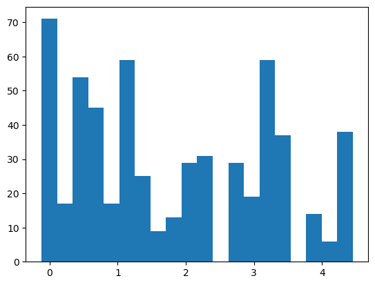

```python
import matplotlib.pyplot as plt

plt.hist(Adatamerge['Interest_rate'],bins=20)
plt.show()
```

### 4.1) log transformation

```python
import numpy as np
Adatamerge['norm'] = (1+Adatamerge.Interest_rate)/2
Adatamerge['log_Interest_rate'] = np.log(Adatamerge['norm'])
Adatamerge.head()
```

|  | cik | gvkey | datadate | conm | revt | ni | year | month | House_price | Interest_rate | norm | log_Interest_rate |
| --- | --- | --- | --- | --- | --- | --- | --- | --- | --- | --- | --- | --- |
| 0 | 0000778946 | 011877 | 2000-03-31 | BLUEGREEN VACATNS CORP | 247.673 | 6.777 | 2000 | 3 | 104.777 | 3.116589 | 2.058295 | 0.721878 |
| 1 | 0001408100 | 025632 | 2000-12-31 | KENNEDY-WILSON HOLDINGS INC | 92.737 | 4.726 | 2000 | 12 | 104.777 | 3.116589 | 2.058295 | 0.721878 |
| 2 | 0001057507 | 110729 | 2000-12-31 | RESORTQUEST INTL INC | 152.014 | 9.606 | 2000 | 12 | 104.777 | 3.116589 | 2.058295 | 0.721878 |
| 3 | 0000216039 | 005357 | 2000-06-30 | GRUBB & ELLIS CO | 413.535 | 16.290 | 2000 | 6 | 104.777 | 3.116589 | 2.058295 | 0.721878 |
| 4 | 0000820917 | 024203 | 2000-12-31 | EQUIVEST FINANCE INC | 158.256 | 10.444 | 2000 | 12 | 104.777 | 3.116589 | 2.058295 | 0.721878 |

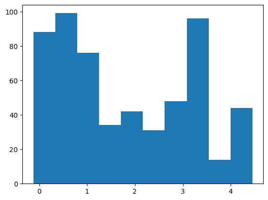

```python
import matplotlib.pyplot as plt

plt.hist(Adatamerge['Interest_rate'])
plt.show()
```

```python
Adatamerge.describe()
```

|  | datadate | revt | ni | year | month | House_price | Interest_rate | norm | log_Interest_rate |
| --- | --- | --- | --- | --- | --- | --- | --- | --- | --- |
| count | 572 | 565.000000 | 565.000000 | 572.000000 | 572.000000 | 571.000000 | 572.000000 | 572.000000 | 572.000000 |
| mean | 2007-03-17 15:08:48.671328768 | 1277.414473 | 12.823004 | 2006.291958 | 11.013986 | 148.177210 | 1.799518 | 1.399759 | 0.197671 |
| min | 1986-12-31 00:00:00 | -356.790000 | -1912.000000 | 1986.000000 | 1.000000 | 66.258167 | -0.119478 | 0.440261 | -0.820388 |
| 25% | 1998-01-23 06:00:00 | 36.151000 | -4.765000 | 1997.750000 | 12.000000 | 90.099667 | 0.589024 | 0.794512 | -0.230027 |
| 50% | 2007-12-31 00:00:00 | 255.030000 | 1.192000 | 2007.000000 | 12.000000 | 144.666667 | 1.445796 | 1.222898 | 0.201223 |
| 75% | 2016-12-31 00:00:00 | 904.499000 | 24.557000 | 2016.000000 | 12.000000 | 180.914250 | 3.116589 | 2.058295 | 0.721878 |
| max | 2022-12-31 00:00:00 | 30828.246000 | 1407.370000 | 2022.000000 | 12.000000 | 298.523000 | 4.452901 | 2.726451 | 1.003001 |
| std | NaN | 2857.895545 | 219.147399 | 10.466546 | 2.584437 | 61.984855 | 1.385928 | 0.692964 | 0.548037 |

```python
Dmodel2=smf.ols(formula='Interest_rate~House_price',data=Adatamerge)
Dresults2=Dmodel2.fit()
print(Dresults2.summary())
```

```
                            OLS Regression Results
==============================================================================
Dep. Variable:          Interest_rate   R-squared:                       0.592
Model:                            OLS   Adj. R-squared:                  0.591
Method:                 Least Squares   F-statistic:                     826.2
Date:                Mon, 04 Dec 2023   Prob (F-statistic):          6.57e-113
Time:                        00:07:04   Log-Likelihood:                -739.18
No. Observations:                 571   AIC:                             1482.
Df Residuals:                     569   BIC:                             1491.
Df Model:                           1
Covariance Type:            nonrobust
===============================================================================
                  coef    std err          t      P>|t|      [0.025      0.975]
-------------------------------------------------------------------------------
Intercept       4.3415      0.096     45.225      0.000       4.153       4.530
House_price    -0.0172      0.001    -28.744      0.000      -0.018      -0.016
==============================================================================
Omnibus:                        2.105   Durbin-Watson:                   0.045
Prob(Omnibus):                  0.349   Jarque-Bera (JB):                1.856
Skew:                           0.021   Prob(JB):                        0.395
Kurtosis:                       2.724   Cond. No.                         416.
==============================================================================

Notes:
[1] Standard Errors assume that the covariance matrix of the errors is correctly specified.
```

**Observation :**

**1) Prob (F-statistic) - This value is <0.1, so we will consider this regression analysis.**

**2) R-squared - Value is significant as it is between 0 to 1.**

### 4.2) Control variables

```python
Dwhat1=pd.get_dummies(Adatamerge['year'], prefix='y')
Adatamerge = Adatamerge.merge(Dwhat1, how='inner', left_index=True, right_index=True)
Adatamerge.head()
```

|  | cik | gvkey | datadate | conm | revt | ni | year | month | House_price | Interest_rate | ... | y_2013 | y_2014 | y_2015 | y_2016 | y_2017 | y_2018 | y_2019 | y_2020 | y_2021 | y_2022 |
| --- | --- | --- | --- | --- | --- | --- | --- | --- | --- | --- | --- | --- | --- | --- | --- | --- | --- | --- | --- | --- | --- |
| 0 | 0000778946 | 011877 | 2000-03-31 | BLUEGREEN VACATNS CORP | 247.673 | 6.777 | 2000 | 3 | 104.777 | 3.116589 | ... | False | False | False | False | False | False | False | False | False | False |
| 1 | 0001408100 | 025632 | 2000-12-31 | KENNEDY-WILSON HOLDINGS INC | 92.737 | 4.726 | 2000 | 12 | 104.777 | 3.116589 | ... | False | False | False | False | False | False | False | False | False | False |
| 2 | 0001057507 | 110729 | 2000-12-31 | RESORTQUEST INTL INC | 152.014 | 9.606 | 2000 | 12 | 104.777 | 3.116589 | ... | False | False | False | False | False | False | False | False | False | False |
| 3 | 0000216039 | 005357 | 2000-06-30 | GRUBB & ELLIS CO | 413.535 | 16.290 | 2000 | 6 | 104.777 | 3.116589 | ... | False | False | False | False | False | False | False | False | False | False |
| 4 | 0000820917 | 024203 | 2000-12-31 | EQUIVEST FINANCE INC | 158.256 | 10.444 | 2000 | 12 | 104.777 | 3.116589 | ... | False | False | False | False | False | False | False | False | False | False |

5 rows × 49 columns

```python
model2 = smf.ols(formula='log_Interest_rate ~ House_price+y_2013+y_2014+y_2015+y_2016+y_2017+y_2018+y_2019+y_2020+y_2021', data=Adatamerge)
results2 = model2.fit()
print(results2.summary())
```

```
                            OLS Regression Results
==============================================================================
Dep. Variable:      log_Interest_rate   R-squared:                       0.713
Model:                            OLS   Adj. R-squared:                  0.708
Method:                 Least Squares   F-statistic:                     138.9
Date:                Mon, 04 Dec 2023   Prob (F-statistic):          1.53e-144
Time:                        00:07:05   Log-Likelihood:                -109.87
No. Observations:                 571   AIC:                             241.7
Df Residuals:                     560   BIC:                             289.6
Df Model:                          10
Covariance Type:            nonrobust
==================================================================================
                     coef    std err          t      P>|t|      [0.025      0.975]
----------------------------------------------------------------------------------
Intercept          1.0068      0.035     28.399      0.000       0.937       1.076
y_2013[T.True]    -0.7517      0.074    -10.203      0.000      -0.896      -0.607
y_2014[T.True]    -0.4815      0.081     -5.937      0.000      -0.641      -0.322
y_2015[T.True]    -0.4622      0.076     -6.050      0.000      -0.612      -0.312
y_2016[T.True]    -0.5348      0.075     -7.166      0.000      -0.681      -0.388
y_2017[T.True]    -0.2931      0.080     -3.681      0.000      -0.449      -0.137
y_2018[T.True]    -0.0206      0.076     -0.272      0.786      -0.170       0.128
y_2019[T.True]    -0.3290      0.073     -4.527      0.000      -0.472      -0.186
y_2020[T.True]    -0.8278      0.067    -12.384      0.000      -0.959      -0.696
y_2021[T.True]    -0.5621      0.068     -8.263      0.000      -0.696      -0.428
House_price       -0.0045      0.000    -17.637      0.000      -0.005      -0.004
==============================================================================
Omnibus:                      237.368   Durbin-Watson:                   0.041
Prob(Omnibus):                  0.000   Jarque-Bera (JB):              872.706
Skew:                          -1.957   Prob(JB):                    3.12e-190
Kurtosis:                       7.622   Cond. No.                     1.29e+03
==============================================================================

Notes:
[1] Standard Errors assume that the covariance matrix of the errors is correctly specified.
[2] The condition number is large, 1.29e+03. This might indicate that there are
strong multicollinearity or other numerical problems.
```

**Observation :**

**1) Prob (F-statistic) - This value is <0.1, so we will consider this regression analysis.**

**2) R-squared - Value is significant as it is between 0 to 1.**

#

# 5) Regression Analysis (House Price & Real Income) ===================

```python
Fmodel1=smf.ols(formula='House_price~Real_income',data=Sdatamerge)
Fresults1=Fmodel1.fit()
print(Fresults1.summary())
```

```
                            OLS Regression Results
==============================================================================
Dep. Variable:            House_price   R-squared:                       0.896
Model:                            OLS   Adj. R-squared:                  0.895
Method:                 Least Squares   F-statistic:                     4885.
Date:                Mon, 04 Dec 2023   Prob (F-statistic):          1.87e-281
Time:                        00:07:06   Log-Likelihood:                -2520.9
No. Observations:                 571   AIC:                             5046.
Df Residuals:                     569   BIC:                             5054.
Df Model:                           1
Covariance Type:            nonrobust
===============================================================================
                  coef    std err          t      P>|t|      [0.025      0.975]
-------------------------------------------------------------------------------
Intercept     -73.0720      3.275    -22.315      0.000     -79.504     -66.640
Real_income     0.0165      0.000     69.896      0.000       0.016       0.017
==============================================================================
Omnibus:                      126.930   Durbin-Watson:                   0.051
Prob(Omnibus):                  0.000   Jarque-Bera (JB):              229.078
Skew:                           1.302   Prob(JB):                     1.80e-50
Kurtosis:                       4.688   Cond. No.                     5.40e+04
==============================================================================

Notes:
[1] Standard Errors assume that the covariance matrix of the errors is correctly specified.
[2] The condition number is large, 5.4e+04. This might indicate that there are
strong multicollinearity or other numerical problems.
```

**Observation :**

**1) Prob (F-statistic) - This value is <0.1, so we will consider this regression analysis.**

**2) R-squared - Value is significant as it is between 0 to 1.**

**3) coef - Value is positive.**

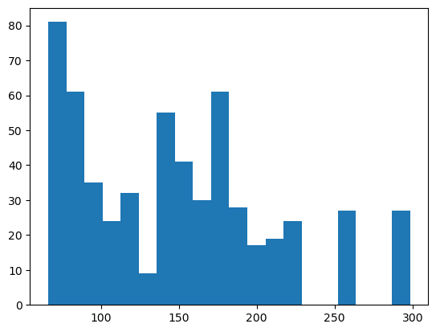

```python
import matplotlib.pyplot as plt

plt.hist(Sdatamerge['House_price'],bins=20)
plt.show()
```

**Observation : House_price distribution is significantly skewed.**

### 5.1) Log transformation

```python
import numpy as np
Sdatamerge['norm'] = (1+Sdatamerge.House_price)/2
Sdatamerge['log_House_price'] = np.log(Sdatamerge['norm'])
Sdatamerge.head()
```

|  | cik | gvkey | datadate | conm | revt | ni | year | month | House_price | Real_income | norm | log_House_price |
| --- | --- | --- | --- | --- | --- | --- | --- | --- | --- | --- | --- | --- |
| 0 | 0000778946 | 011877 | 2000-03-31 | BLUEGREEN VACATNS CORP | 247.673 | 6.777 | 2000 | 3 | 104.777 | 11677.540167 | 52.8885 | 3.968186 |
| 1 | 0001408100 | 025632 | 2000-12-31 | KENNEDY-WILSON HOLDINGS INC | 92.737 | 4.726 | 2000 | 12 | 104.777 | 11677.540167 | 52.8885 | 3.968186 |
| 2 | 0001057507 | 110729 | 2000-12-31 | RESORTQUEST INTL INC | 152.014 | 9.606 | 2000 | 12 | 104.777 | 11677.540167 | 52.8885 | 3.968186 |
| 3 | 0000216039 | 005357 | 2000-06-30 | GRUBB & ELLIS CO | 413.535 | 16.290 | 2000 | 6 | 104.777 | 11677.540167 | 52.8885 | 3.968186 |
| 4 | 0000820917 | 024203 | 2000-12-31 | EQUIVEST FINANCE INC | 158.256 | 10.444 | 2000 | 12 | 104.777 | 11677.540167 | 52.8885 | 3.968186 |

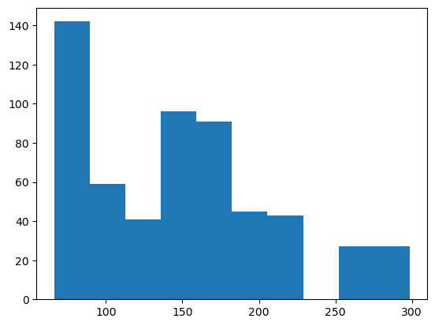

```python
import matplotlib.pyplot as plt

plt.hist(Sdatamerge['House_price'])
plt.show()
```

```python
Sdatamerge.describe()
```

|  | datadate | revt | ni | year | month | House_price | Real_income | norm | log_House_price |
| --- | --- | --- | --- | --- | --- | --- | --- | --- | --- |
| count | 572 | 565.000000 | 565.000000 | 572.000000 | 572.000000 | 571.000000 | 572.000000 | 571.000000 | 571.000000 |
| mean | 2007-03-17 15:08:48.671328768 | 1277.414473 | 12.823004 | 2006.291958 | 11.013986 | 148.177210 | 13361.274170 | 74.588605 | 4.226242 |
| min | 1986-12-31 00:00:00 | -356.790000 | -1912.000000 | 1986.000000 | 1.000000 | 66.258167 | 7284.574917 | 33.629083 | 3.515391 |
| 25% | 1998-01-23 06:00:00 | 36.151000 | -4.765000 | 1997.750000 | 12.000000 | 90.099667 | 10530.969688 | 45.549833 | 3.818807 |
| 50% | 2007-12-31 00:00:00 | 255.030000 | 1.192000 | 2007.000000 | 12.000000 | 144.666667 | 13569.493333 | 72.833333 | 4.288174 |
| 75% | 2016-12-31 00:00:00 | 904.499000 | 24.557000 | 2016.000000 | 12.000000 | 180.914250 | 16164.609833 | 90.957125 | 4.510388 |
| max | 2022-12-31 00:00:00 | 30828.246000 | 1407.370000 | 2022.000000 | 12.000000 | 298.523000 | 19649.086583 | 149.761500 | 5.009044 |
| std | NaN | 2857.895545 | 219.147399 | 10.466546 | 2.584437 | 61.984855 | 3551.499231 | 30.992427 | 0.416955 |

```python
Fmodel2=smf.ols(formula='House_price~Real_income',data=Sdatamerge)
results=Fmodel2.fit()
print(results.summary())
```

```
                            OLS Regression Results
==============================================================================
Dep. Variable:            House_price   R-squared:                       0.896
Model:                            OLS   Adj. R-squared:                  0.895
Method:                 Least Squares   F-statistic:                     4885.
Date:                Mon, 04 Dec 2023   Prob (F-statistic):          1.87e-281
Time:                        00:07:08   Log-Likelihood:                -2520.9
No. Observations:                 571   AIC:                             5046.
Df Residuals:                     569   BIC:                             5054.
Df Model:                           1
Covariance Type:            nonrobust
===============================================================================
                  coef    std err          t      P>|t|      [0.025      0.975]
-------------------------------------------------------------------------------
Intercept     -73.0720      3.275    -22.315      0.000     -79.504     -66.640
Real_income     0.0165      0.000     69.896      0.000       0.016       0.017
==============================================================================
Omnibus:                      126.930   Durbin-Watson:                   0.051
Prob(Omnibus):                  0.000   Jarque-Bera (JB):              229.078
Skew:                           1.302   Prob(JB):                     1.80e-50
Kurtosis:                       4.688   Cond. No.                     5.40e+04
==============================================================================

Notes:
[1] Standard Errors assume that the covariance matrix of the errors is correctly specified.
[2] The condition number is large, 5.4e+04. This might indicate that there are
strong multicollinearity or other numerical problems.
```

**Observation :**

**1) Prob (F-statistic) - This value is <0.1, so we will consider this regression analysis.**

**2) R-squared - Value is significant as it is between 0 to 1.**

**3) coef - Value is positive.**

### 5.2) Control variables

```python
Fwhat1=pd.get_dummies(Sdatamerge['year'], prefix='y')
Sdatamerge = Sdatamerge.merge(Fwhat1, how='inner', left_index=True, right_index=True)
Sdatamerge.head()
```

|  | cik | gvkey | datadate | conm | revt | ni | year | month | House_price | Real_income | ... | y_2013 | y_2014 | y_2015 | y_2016 | y_2017 | y_2018 | y_2019 | y_2020 | y_2021 | y_2022 |
| --- | --- | --- | --- | --- | --- | --- | --- | --- | --- | --- | --- | --- | --- | --- | --- | --- | --- | --- | --- | --- | --- |
| 0 | 0000778946 | 011877 | 2000-03-31 | BLUEGREEN VACATNS CORP | 247.673 | 6.777 | 2000 | 3 | 104.777 | 11677.540167 | ... | False | False | False | False | False | False | False | False | False | False |
| 1 | 0001408100 | 025632 | 2000-12-31 | KENNEDY-WILSON HOLDINGS INC | 92.737 | 4.726 | 2000 | 12 | 104.777 | 11677.540167 | ... | False | False | False | False | False | False | False | False | False | False |
| 2 | 0001057507 | 110729 | 2000-12-31 | RESORTQUEST INTL INC | 152.014 | 9.606 | 2000 | 12 | 104.777 | 11677.540167 | ... | False | False | False | False | False | False | False | False | False | False |
| 3 | 0000216039 | 005357 | 2000-06-30 | GRUBB & ELLIS CO | 413.535 | 16.290 | 2000 | 6 | 104.777 | 11677.540167 | ... | False | False | False | False | False | False | False | False | False | False |
| 4 | 0000820917 | 024203 | 2000-12-31 | EQUIVEST FINANCE INC | 158.256 | 10.444 | 2000 | 12 | 104.777 | 11677.540167 | ... | False | False | False | False | False | False | False | False | False | False |

5 rows × 49 columns

```python
Fmodel3 = smf.ols(formula='log_House_price ~ Real_income+y_2013+y_2014+y_2015+y_2016+y_2017+y_2018+y_2019+y_2020+y_2021', data=Sdatamerge)
Fresults3 = Fmodel3.fit()
print(Fresults3.summary())
```

```
                            OLS Regression Results
==============================================================================
Dep. Variable:        log_House_price   R-squared:                       0.954
Model:                            OLS   Adj. R-squared:                  0.954
Method:                 Least Squares   F-statistic:                     1173.
Date:                Mon, 04 Dec 2023   Prob (F-statistic):               0.00
Time:                        00:07:09   Log-Likelihood:                 571.57
No. Observations:                 571   AIC:                            -1121.
Df Residuals:                     560   BIC:                            -1073.
Df Model:                          10
Covariance Type:            nonrobust
==================================================================================
                     coef    std err          t      P>|t|      [0.025      0.975]
----------------------------------------------------------------------------------
Intercept          2.5280      0.019    133.774      0.000       2.491       2.565
y_2013[T.True]    -0.0941      0.023     -4.150      0.000      -0.139      -0.050
y_2014[T.True]    -0.1006      0.025     -4.026      0.000      -0.150      -0.051
y_2015[T.True]    -0.1454      0.024     -6.120      0.000      -0.192      -0.099
y_2016[T.True]    -0.1303      0.023     -5.607      0.000      -0.176      -0.085
y_2017[T.True]    -0.1393      0.025     -5.621      0.000      -0.188      -0.091
y_2018[T.True]    -0.1505      0.024     -6.339      0.000      -0.197      -0.104
y_2019[T.True]    -0.1896      0.023     -8.242      0.000      -0.235      -0.144
y_2020[T.True]    -0.2654      0.022    -12.208      0.000      -0.308      -0.223
y_2021[T.True]    -0.2245      0.022    -10.389      0.000      -0.267      -0.182
Real_income        0.0001   1.55e-06     84.070      0.000       0.000       0.000
==============================================================================
Omnibus:                       62.514   Durbin-Watson:                   0.030
Prob(Omnibus):                  0.000   Jarque-Bera (JB):              107.258
Skew:                           0.699   Prob(JB):                     5.12e-24
Kurtosis:                       4.599   Cond. No.                     1.36e+05
==============================================================================

Notes:
[1] Standard Errors assume that the covariance matrix of the errors is correctly specified.
[2] The condition number is large, 1.36e+05. This might indicate that there are
strong multicollinearity or other numerical problems.
```

**Observation :**

**1) Prob (F-statistic) - This value is <0.1, so we will consider this regression analysis.**

**2) R-squared - Value is significant as it is between 0 to 1.**

**3) coef - Value is positive.**

# 6) Regression Analysis (Real Income & Interest Rate) ================

```python
Gmodel1=smf.ols(formula='Real_income~Interest_rate',data=Asdata)
Gresults1=Gmodel1.fit()
print(Gresults1.summary())
```

```
                            OLS Regression Results
==============================================================================
Dep. Variable:            Real_income   R-squared:                       0.791
Model:                            OLS   Adj. R-squared:                  0.791
Method:                 Least Squares   F-statistic:                 3.726e+04
Date:                Mon, 04 Dec 2023   Prob (F-statistic):               0.00
Time:                        00:07:10   Log-Likelihood:                -86809.
No. Observations:                9826   AIC:                         1.736e+05
Df Residuals:                    9824   BIC:                         1.736e+05
Df Model:                           1
Covariance Type:            nonrobust
=================================================================================
                    coef    std err          t      P>|t|      [0.025      0.975]
---------------------------------------------------------------------------------
Intercept      1.785e+04     25.986    686.709      0.000    1.78e+04    1.79e+04
Interest_rate -2369.3983     12.275   -193.027      0.000   -2393.460   -2345.337
==============================================================================
Omnibus:                      132.991   Durbin-Watson:                   0.002
Prob(Omnibus):                  0.000   Jarque-Bera (JB):              114.276
Skew:                           0.206   Prob(JB):                     1.53e-25
Kurtosis:                       2.668   Cond. No.                         3.75
==============================================================================

Notes:
[1] Standard Errors assume that the covariance matrix of the errors is correctly specified.
```

**Observation :**

**1) Prob (F-statistic) - This value is <0.1, so we will consider this regression analysis.**

**2) R-squared - Value is significant as it is between 0 to 1.**

**3) coef - Value is Negative.**

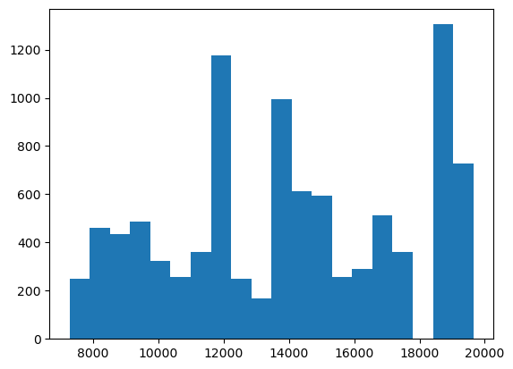

```python
import matplotlib.pyplot as plt

plt.hist(Asdata['Real_income'],bins=20)
plt.show()
```

### 6.1) Log transformation

```python
import numpy as np
Asdata['norm'] = (1+Asdata.Real_income)/2
Asdata['log_Real_income'] = np.log(Asdata['norm'])
Asdata.head()
```

|  | cik_x | gvkey_x | datadate_x | conm_x | revt_x | ni_x | year | month_x | Interest_rate | cik_y | gvkey_y | datadate_y | conm_y | revt_y | ni_y | month_y | Real_income | norm | log_Real_income |
| --- | --- | --- | --- | --- | --- | --- | --- | --- | --- | --- | --- | --- | --- | --- | --- | --- | --- | --- | --- |
| 0 | 0000778946 | 011877 | 2000-03-31 | BLUEGREEN VACATNS CORP | 247.673 | 6.777 | 2000 | 3 | 3.116589 | 0000778946 | 011877 | 2000-03-31 | BLUEGREEN VACATNS CORP | 247.673 | 6.777 | 3 | 11677.540167 | 5839.270083 | 8.672361 |
| 1 | 0000778946 | 011877 | 2000-03-31 | BLUEGREEN VACATNS CORP | 247.673 | 6.777 | 2000 | 3 | 3.116589 | 0001408100 | 025632 | 2000-12-31 | KENNEDY-WILSON HOLDINGS INC | 92.737 | 4.726 | 12 | 11677.540167 | 5839.270083 | 8.672361 |
| 2 | 0000778946 | 011877 | 2000-03-31 | BLUEGREEN VACATNS CORP | 247.673 | 6.777 | 2000 | 3 | 3.116589 | 0001057507 | 110729 | 2000-12-31 | RESORTQUEST INTL INC | 152.014 | 9.606 | 12 | 11677.540167 | 5839.270083 | 8.672361 |
| 3 | 0000778946 | 011877 | 2000-03-31 | BLUEGREEN VACATNS CORP | 247.673 | 6.777 | 2000 | 3 | 3.116589 | 0000216039 | 005357 | 2000-06-30 | GRUBB & ELLIS CO | 413.535 | 16.290 | 6 | 11677.540167 | 5839.270083 | 8.672361 |
| 4 | 0000778946 | 011877 | 2000-03-31 | BLUEGREEN VACATNS CORP | 247.673 | 6.777 | 2000 | 3 | 3.116589 | 0000820917 | 024203 | 2000-12-31 | EQUIVEST FINANCE INC | 158.256 | 10.444 | 12 | 11677.540167 | 5839.270083 | 8.672361 |

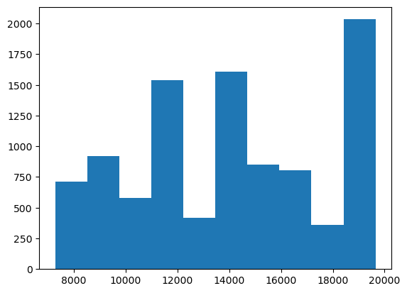

```python
import matplotlib.pyplot as plt

plt.hist(Asdata['Real_income'])
plt.show()
```

```python
Asdata.describe()
```

|  | datadate_x | revt_x | ni_x | year | month_x | Interest_rate | datadate_y | revt_y | ni_y | month_y | Real_income | norm | log_Real_income |
| --- | --- | --- | --- | --- | --- | --- | --- | --- | --- | --- | --- | --- | --- |
| count | 9826 | 9735.000000 | 9735.000000 | 9826.000000 | 9826.000000 | 9826.000000 | 9826 | 9735.000000 | 9735.000000 | 9826.000000 | 9826.000000 | 9826.000000 | 9826.000000 |
| mean | 2008-12-25 17:34:34.414818048 | 1518.484171 | 12.094664 | 2008.057093 | 11.156931 | 1.617454 | 2008-12-25 17:34:34.414817792 | 1518.484171 | 12.094664 | 11.156931 | 14012.657469 | 7006.828735 | 8.818545 |
| min | 1986-12-31 00:00:00 | -356.790000 | -1912.000000 | 1986.000000 | 1.000000 | -0.119478 | 1986-12-31 00:00:00 | -356.790000 | -1912.000000 | 1.000000 | 7284.574917 | 3642.787458 | 8.200504 |
| 25% | 1999-12-31 00:00:00 | 52.129000 | -8.359000 | 1999.000000 | 12.000000 | 0.526061 | 1999-12-31 00:00:00 | 52.129000 | -8.359000 | 12.000000 | 11080.506667 | 5540.753333 | 8.619886 |
| 50% | 2010-12-31 00:00:00 | 289.522000 | 1.167000 | 2010.000000 | 12.000000 | 1.156195 | 2010-12-31 00:00:00 | 289.522000 | 1.167000 | 12.000000 | 13934.991083 | 6967.995542 | 8.849083 |
| 75% | 2018-12-31 00:00:00 | 1264.523000 | 27.704000 | 2018.000000 | 12.000000 | 2.886970 | 2018-12-31 00:00:00 | 1264.523000 | 27.704000 | 12.000000 | 17175.824833 | 8588.412417 | 9.058169 |
| max | 2022-12-31 00:00:00 | 30828.246000 | 1407.370000 | 2022.000000 | 12.000000 | 4.452901 | 2022-12-31 00:00:00 | 30828.246000 | 1407.370000 | 12.000000 | 19649.086583 | 9825.043292 | 9.192690 |
| std | NaN | 3273.684693 | 234.355147 | 10.468472 | 2.401908 | 1.365944 | NaN | 3273.684693 | 234.355147 | 2.401908 | 3638.203852 | 1819.101926 | 0.274088 |

```python
Gmodel2=smf.ols(formula='Real_income~Interest_rate',data=Asdata)
Gresults2=Gmodel2.fit()
print(Gresults2.summary())
```

```
                            OLS Regression Results
==============================================================================
Dep. Variable:            Real_income   R-squared:                       0.791
Model:                            OLS   Adj. R-squared:                  0.791
Method:                 Least Squares   F-statistic:                 3.726e+04
Date:                Mon, 04 Dec 2023   Prob (F-statistic):               0.00
Time:                        00:07:12   Log-Likelihood:                -86809.
No. Observations:                9826   AIC:                         1.736e+05
Df Residuals:                    9824   BIC:                         1.736e+05
Df Model:                           1
Covariance Type:            nonrobust
=================================================================================
                    coef    std err          t      P>|t|      [0.025      0.975]
---------------------------------------------------------------------------------
Intercept      1.785e+04     25.986    686.709      0.000    1.78e+04    1.79e+04
Interest_rate -2369.3983     12.275   -193.027      0.000   -2393.460   -2345.337
==============================================================================
Omnibus:                      132.991   Durbin-Watson:                   0.002
Prob(Omnibus):                  0.000   Jarque-Bera (JB):              114.276
Skew:                           0.206   Prob(JB):                     1.53e-25
Kurtosis:                       2.668   Cond. No.                         3.75
==============================================================================

Notes:
[1] Standard Errors assume that the covariance matrix of the errors is correctly specified.
```

**Observation :**

**1) Prob (F-statistic) - This value is <0.1, so we will consider this regression analysis.**

**2) R-squared - Value is significant as it is between 0 to 1.**

**3) coef - Value is Negative.**

### 6.2) Control variables

```python
Gwhat1=pd.get_dummies(Asdata['year'], prefix='y')
Asdata = Asdata.merge(Gwhat1, how='inner', left_index=True, right_index=True)
Asdata.head()
```

|  | cik_x | gvkey_x | datadate_x | conm_x | revt_x | ni_x | year | month_x | Interest_rate | cik_y | ... | y_2013 | y_2014 | y_2015 | y_2016 | y_2017 | y_2018 | y_2019 | y_2020 | y_2021 | y_2022 |
| --- | --- | --- | --- | --- | --- | --- | --- | --- | --- | --- | --- | --- | --- | --- | --- | --- | --- | --- | --- | --- | --- |
| 0 | 0000778946 | 011877 | 2000-03-31 | BLUEGREEN VACATNS CORP | 247.673 | 6.777 | 2000 | 3 | 3.116589 | 0000778946 | ... | False | False | False | False | False | False | False | False | False | False |
| 1 | 0000778946 | 011877 | 2000-03-31 | BLUEGREEN VACATNS CORP | 247.673 | 6.777 | 2000 | 3 | 3.116589 | 0001408100 | ... | False | False | False | False | False | False | False | False | False | False |
| 2 | 0000778946 | 011877 | 2000-03-31 | BLUEGREEN VACATNS CORP | 247.673 | 6.777 | 2000 | 3 | 3.116589 | 0001057507 | ... | False | False | False | False | False | False | False | False | False | False |
| 3 | 0000778946 | 011877 | 2000-03-31 | BLUEGREEN VACATNS CORP | 247.673 | 6.777 | 2000 | 3 | 3.116589 | 0000216039 | ... | False | False | False | False | False | False | False | False | False | False |
| 4 | 0000778946 | 011877 | 2000-03-31 | BLUEGREEN VACATNS CORP | 247.673 | 6.777 | 2000 | 3 | 3.116589 | 0000820917 | ... | False | False | False | False | False | False | False | False | False | False |

5 rows × 56 columns

```python
Gmodel3 = smf.ols(formula='log_Real_income ~ Interest_rate+y_2013+y_2014+y_2015+y_2016+y_2017+y_2018+y_2019+y_2020+y_2021', data=Asdata)
Gresults3 = Gmodel3.fit()
print(Gresults3.summary())
```

```
                            OLS Regression Results
==============================================================================
Dep. Variable:        log_Real_income   R-squared:                       0.864
Model:                            OLS   Adj. R-squared:                  0.864
Method:                 Least Squares   F-statistic:                     6254.
Date:                Mon, 04 Dec 2023   Prob (F-statistic):               0.00
Time:                        00:07:13   Log-Likelihood:                 8590.4
No. Observations:                9826   AIC:                        -1.716e+04
Df Residuals:                    9815   BIC:                        -1.708e+04
Df Model:                          10
Covariance Type:            nonrobust
==================================================================================
                     coef    std err          t      P>|t|      [0.025      0.975]
----------------------------------------------------------------------------------
Intercept          9.0828      0.003   3518.312      0.000       9.078       9.088
y_2013[T.True]    -0.1313      0.006    -20.568      0.000      -0.144      -0.119
y_2014[T.True]    -0.0395      0.008     -5.263      0.000      -0.054      -0.025
y_2015[T.True]     0.0003      0.007      0.048      0.962      -0.013       0.013
y_2016[T.True]    -0.0125      0.006     -1.973      0.048      -0.025   -8.31e-05
y_2017[T.True]     0.0706      0.007     10.066      0.000       0.057       0.084
y_2018[T.True]     0.1755      0.006     28.452      0.000       0.163       0.188
y_2019[T.True]     0.0999      0.006     17.446      0.000       0.089       0.111
y_2020[T.True]     0.0429      0.005      8.592      0.000       0.033       0.053
y_2021[T.True]     0.1044      0.005     22.883      0.000       0.095       0.113
Interest_rate     -0.1731      0.001   -171.301      0.000      -0.175      -0.171
==============================================================================
Omnibus:                      882.927   Durbin-Watson:                   0.003
Prob(Omnibus):                  0.000   Jarque-Bera (JB):             1313.601
Skew:                           0.700   Prob(JB):                    5.69e-286
Kurtosis:                       4.117   Cond. No.                         20.2
==============================================================================

Notes:
[1] Standard Errors assume that the covariance matrix of the errors is correctly specified.
```

**Observation :**

**1) Prob (F-statistic) - This value is <0.1, so we will consider this regression analysis.**

**2) R-squared - Value is significant as it is between 0 to 1.**